# Measuring Socioeconomic Effects of PM2.5 Levels

### Final Data Science Tutorial – CMPS 6160

Peter Carroll | Spring 2025

Link to website: https://pcarroll16.github.io/index%20(5).html

# Measuring Socioeconomic Effects of PM2.5 Levels

## Motivation and Introduction

Fine particulate matter, known as PM2.5, consists of tiny airborne particles less than 2.5 micrometers in diameter. These particles are generated by industrial activities, vehicle emissions, and atmospheric chemical reactions. Due to their size, PM2.5 particles can penetrate deep into the lungs and bloodstream, leading to various adverse health outcomes including respiratory diseases, cardiovascular complications, and neurological disorders.

Understanding the impact of PM2.5 pollution on both public health and local economies is a critical issue for environmental data science. The U.S. Environmental Protection Agency (EPA) defines safe exposure levels, but counties that exceed the annual mean threshold (12 µg/m³ as of 2018) — known as nonattainment areas — face not only regulatory penalties but also health and economic consequences that are not well quantified.

This project explores whether PM2.5 levels correlate with:

- Increased mortality from respiratory and nervous system diseases
- Industry-specific employment patterns, particularly in pollution-intensive sectors

I construct and evaluate a classification model to predict which counties exceed the EPA’s 2018 PM2.5 threshold, using health and economic indicators to inform my prediction and policy recommendations.

## Initial Research Question

How do trends in fine particulate matter (PM2.5) concentrations relate to economic indicators such as employment levels and average wages—specifically in pollution-linked sectors like manufacturing and agriculture?

This research explores both correlational and predictive frameworks. I aim to describe potential relationships and assess whether air quality is a statistically significant predictor of economic or health outcomes at the county level.

**Focused Research Questions**

Are counties with higher PM2.5 levels more likely to have higher mortality from respiratory or nervous system illnesses? Does employment in certain industries (e.g., manufacturing, agriculture) correlate with higher pollution or mortality rates? Can I predict PM2.5 nonattainment using public health and employment data?

## Hypothesis

Based on prior literature and policy assumptions, my hypothesis is the following:

> Counties with higher levels of PM2.5 pollution will exhibit:
> - Higher crude death rates from respiratory and nervous system diseases
> - Greater employment concentrations in historically pollution-intensive sectors, such as manufacturing and utilities

Additionally, I expect that:

- The association between PM2.5 and mortality will be stronger in counties exceeding the EPA's annual PM2.5 standard of 12 µg/m³.

This hypothesis motivates both the exploratory and modeling components of the analysis.

## Data Setup and Library Imports

I begin by installing necessary packages and loading core libraries for analysis. All data files are stored in Google Drive for easy access in this Colab environment.

```python
# Install necessary packages and libraries
!pip install xlrd
import pandas as pd
import numpy as np
import matplotlib.pyplot as plt
import seaborn as sns

# Mount Drive
from google.colab import drive
drive.mount('/content/drive')
```

```python
# Load datasets from Google Drive
pm25_path = '/content/drive/MyDrive/CMPS Project Data/annual_conc_by_monitor_2018.csv'

df_pm25 = pd.read_csv(pm25_path)
```

```python
# Bls
bls_path = '/content/drive/MyDrive/CMPS Project Data/state_M2018_dl.xlsx'
df_bls_state = pd.read_excel(bls_path, skiprows=4)
```

```python
#CDC county level deaths
cpath_1 = '/content/drive/MyDrive/CMPS Project Data/County Deaths nervous.xlsx'
cpath_2 = '/content/drive/MyDrive/CMPS Project Data/County Deaths immune.xlsx'
cpath_3 = '/content/drive/MyDrive/CMPS Project Data/County Deaths resp.xlsx'

nerv_df = pd.read_excel(cpath_1)
immune_df = pd.read_excel(cpath_2)
resp_df = pd.read_excel(cpath_3)
```

```python
#County level industry data
industry_path = '/content/drive/MyDrive/CMPS Project Data/County Industry.csv'
industry_county = pd.read_csv(industry_path, header = 1)
```

|  | Geography | Geographic Area Name | Estimate!!Total | Margin of Error!!Total | Estimate!!Total!!Male | Margin of Error!!Total!!Male | Estimate!!Total!!Male!!Agriculture, forestry, fishing and hunting, and mining | Margin of Error!!Total!!Male!!Agriculture, forestry, fishing and hunting, and mining | Estimate!!Total!!Male!!Agriculture, forestry, fishing and hunting, and mining!!Agriculture, forestry, fishing and hunting | Margin of Error!!Total!!Male!!Agriculture, forestry, fishing and hunting, and mining!!Agriculture, forestry, fishing and hunting | ... | Margin of Error!!Total!!Female!!Arts, entertainment, and recreation, and accommodation and food services | Estimate!!Total!!Female!!Arts, entertainment, and recreation, and accommodation and food services!!Arts, entertainment, and recreation | Margin of Error!!Total!!Female!!Arts, entertainment, and recreation, and accommodation and food services!!Arts, entertainment, and recreation | Estimate!!Total!!Female!!Arts, entertainment, and recreation, and accommodation and food services!!Accommodation and food services | Margin of Error!!Total!!Female!!Arts, entertainment, and recreation, and accommodation and food services!!Accommodation and food services | Estimate!!Total!!Female!!Other services, except public administration | Margin of Error!!Total!!Female!!Other services, except public administration | Estimate!!Total!!Female!!Public administration | Margin of Error!!Total!!Female!!Public administration | Unnamed: 112 |
| --- | --- | --- | --- | --- | --- | --- | --- | --- | --- | --- | --- | --- | --- | --- | --- | --- | --- | --- | --- | --- | --- |
| 0 | 0500000US01003 | Baldwin County, Alabama | 102800.0 | 4327.0 | 50739.0 | 2779.0 | 957.0 | 642.0 | 509.0 | 391.0 | ... | 1655.0 | 1228.0 | 614.0 | 6318.0 | 1661.0 | 3281.0 | 1154.0 | 2015.0 | 722.0 | NaN |
| 1 | 0500000US01015 | Calhoun County, Alabama | 49415.0 | 3039.0 | 25878.0 | 1907.0 | 382.0 | 491.0 | 333.0 | 485.0 | ... | 1026.0 | 278.0 | 323.0 | 2350.0 | 860.0 | 1644.0 | 762.0 | 1239.0 | 538.0 | NaN |
| 2 | 0500000US01043 | Cullman County, Alabama | 35876.0 | 1979.0 | 19369.0 | 1284.0 | 418.0 | 298.0 | 246.0 | 205.0 | ... | 779.0 | 468.0 | 395.0 | 1838.0 | 749.0 | 853.0 | 418.0 | 106.0 | 120.0 | NaN |
| 3 | 0500000US01049 | DeKalb County, Alabama | 29616.0 | 2399.0 | 15878.0 | 1434.0 | 614.0 | 412.0 | 614.0 | 412.0 | ... | 672.0 | 75.0 | 127.0 | 1538.0 | 637.0 | 1479.0 | 752.0 | 165.0 | 169.0 | NaN |
| 4 | 0500000US01051 | Elmore County, Alabama | 34265.0 | 2312.0 | 16640.0 | 1538.0 | 609.0 | 434.0 | 328.0 | 326.0 | ... | 782.0 | 712.0 | 617.0 | 1536.0 | 542.0 | 1122.0 | 662.0 | 1854.0 | 837.0 | NaN |

5 rows × 113 columns

## Data Sources and Cleaning: State Level

First, I will merge in data for state level analysis from:

- **EPA AQS (2018):** County-level annual mean PM2.5 concentrations.
- **Bureau of Labor Statistics (2018):** State-level employment and wage data across industries.

**Data Cleaning: BLS**

First, I begin with state-level employment data from the BLS. My focus is on aggregating and isolating manufacturing employment across states. This industry serves as a proxy for pollution-intensive economic activity, due to its known contribution to emissions and historical links to PM2.5 exposure.

To prepare this data, I needed to:

- Clean column names for clarity.
- Filter for manufacturing-related occupation codes.

```python
# Clean BLS data
#Rename columns for clarity
df_bls_state.columns = [
    'state_code', 'state_abbr', 'state_name', 'occupation_code', 'occupation_title',
    'level', 'employment', 'employment_RSE', 'emp_per_1000_jobs', 'location_quotient',
    'median_hourly_wage', 'mean_hourly_wage', 'annual_mean_wage', 'percentile_10_hourly',
    'percentile_25_hourly', 'percentile_50_hourly', 'percentile_75_hourly', 'percentile_90_hourly',
    'annual_10th', 'annual_25th', 'annual_median', 'annual_75th', 'annual_90th', 'footnote_1', 'footnote_2'
]

# Clean numeric columns
for col in ['employment', 'annual_mean_wage']:
    df_bls_state[col] = df_bls_state[col].replace(['*', '**', '#'], pd.NA)
    df_bls_state[col] = df_bls_state[col].astype(str).str.replace(',', '', regex=False)
    df_bls_state[col] = pd.to_numeric(df_bls_state[col], errors='coerce')

# Filter for manufacturing-related occupations
manufacturing_keywords = ['Production', 'Plant', 'Industrial', 'Machinist', 'Assembler',
            'Machine', 'Mining', 'Agriculture', 'Construction']
df_mfg = df_bls_state[
    df_bls_state['occupation_title'].str.contains('|'.join(manufacturing_keywords), case=False, na=False)
]

df_mfg = df_mfg.dropna(subset=['employment', 'annual_mean_wage'])
```

```python
# Aggregate manufacturing employment by state
df_mfg_agg = df_mfg.groupby('state_name').agg({
    'employment': 'sum',
    'annual_mean_wage': 'mean'
}).reset_index()
```

```python
df_mfg.head()
```

|  | state_code | state_abbr | state_name | occupation_code | occupation_title | level | employment | employment_RSE | emp_per_1000_jobs | location_quotient | ... | percentile_50_hourly | percentile_75_hourly | percentile_90_hourly | annual_10th | annual_25th | annual_median | annual_75th | annual_90th | footnote_1 | footnote_2 |
| --- | --- | --- | --- | --- | --- | --- | --- | --- | --- | --- | --- | --- | --- | --- | --- | --- | --- | --- | --- | --- | --- |
| 8 | 1 | AL | Alabama | 11-3051 | Industrial Production Managers | detailed | 3530.0 | 4 | 1.817 | 1.45 | ... | 46.52 | 59.23 | 76.03 | 60030 | 76330 | 96770 | 123200 | 158150 | NaN | NaN |
| 14 | 1 | AL | Alabama | 11-9021 | Construction Managers | detailed | 2850.0 | 5.5 | 1.464 | 0.76 | ... | 41.51 | 52.97 | 70.66 | 54040 | 68280 | 86350 | 110180 | 146960 | NaN | NaN |
| 88 | 1 | AL | Alabama | 17-2111 | Health and Safety Engineers, Except Mining Saf... | detailed | 500.0 | 12.6 | 0.259 | 1.43 | ... | 46.51 | 56.46 | 64.93 | 61980 | 76660 | 96750 | 117450 | 135060 | NaN | NaN |
| 89 | 1 | AL | Alabama | 17-2112 | Industrial Engineers | detailed | 5630.0 | 2.9 | 2.897 | 1.5 | ... | 40.65 | 49.66 | 61.12 | 55230 | 68780 | 84540 | 103290 | 127130 | NaN | NaN |
| 93 | 1 | AL | Alabama | 17-2151 | Mining and Geological Engineers, Including Min... | detailed | 180.0 | 13.8 | 0.094 | 2.36 | ... | 43.99 | 52.34 | 68.07 | 57670 | 73750 | 91510 | 108870 | 141590 | NaN | NaN |

5 rows × 25 columns

```python
# Basic statistics
df_mfg[['employment', 'annual_mean_wage']].describe()
```

|  | employment | annual_mean_wage |
| --- | --- | --- |
| count | 3483.000000 | 3483.000000 |
| mean | 7545.188056 | 3.468045 |
| std | 37257.326438 | 2.310242 |
| min | 30.000000 | 0.400000 |
| 25% | 300.000000 | 2.000000 |
| 50% | 960.000000 | 2.900000 |
| 75% | 3235.000000 | 4.200000 |
| max | 836260.000000 | 20.500000 |

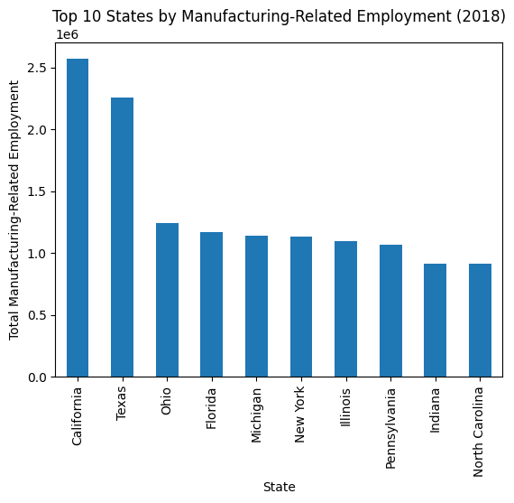

```python
# Bar plot for manufacturing by state
df_state_agg = df_mfg_agg.groupby('state_name')['employment'].sum().dropna().sort_values(ascending=False).head(10)

df_state_agg.plot(kind='bar')
plt.ylabel('Total Manufacturing-Related Employment')
plt.xlabel('State')
plt.title('Top 10 States by Manufacturing-Related Employment (2018)')
plt.show()
```

## Cleaning and Exploratory Analysis: PM2.5 Data

Next, I will clean and explore the EPA AQS data, focusing on mean annual PM2.5 values from 2018. Each row represents an observation from a county monitoring site.

Steps:

- Filter only for PM2.5 measurements under local conditions.
- Drop missing values and focus on relevant columns.
- Aggregate PM2.5 data to the state level to support initial exploratory comparisons.

This aggregation provides a useful macro view of which states had relatively high or low particulate matter pollution in 2018.

```python
# Clean PM2.5 data
df_pm25_clean = df_pm25[df_pm25['Parameter Name'] == 'PM2.5 - Local Conditions']
pm25 = df_pm25_clean[['County Name', 'State Name', 'Arithmetic Mean']].dropna()
pm25.head()
```

|  | County Name | State Name | Arithmetic Mean |
| --- | --- | --- | --- |
| 4 | Baldwin | Alabama | 7.158879 |
| 5 | Baldwin | Alabama | 7.158879 |
| 6 | Baldwin | Alabama | 7.158879 |
| 7 | Baldwin | Alabama | 7.158879 |
| 8 | Baldwin | Alabama | 7.158879 |

```python
# Aggregate PM2.5 by state (mean concentration)
df_pm25_agg = df_pm25_clean.groupby('State Name')['Arithmetic Mean'].mean().reset_index()
df_pm25_agg.columns = ['state_name', 'avg_pm25']

df_pm25_agg.head()
```

|  | state_name | avg_pm25 |
| --- | --- | --- |
| 0 | Alabama | 8.517442 |
| 1 | Alaska | 7.966343 |
| 2 | Arizona | 7.948104 |
| 3 | Arkansas | 8.780321 |
| 4 | California | 10.470187 |

```python
# Merge Datasets
df_merged = pd.merge(df_mfg_agg, df_pm25_agg, on='state_name', how='inner')

df_merged.head()
```

|  | state_name | employment | annual_mean_wage | avg_pm25 |
| --- | --- | --- | --- | --- |
| 0 | Alabama | 521480.0 | 3.094805 | 8.517442 |
| 1 | Alaska | 44540.0 | 4.748780 | 7.966343 |
| 2 | Arizona | 405400.0 | 3.472857 | 7.948104 |
| 3 | Arkansas | 280960.0 | 3.679710 | 8.780321 |
| 4 | California | 2570730.0 | 2.485000 | 10.470187 |

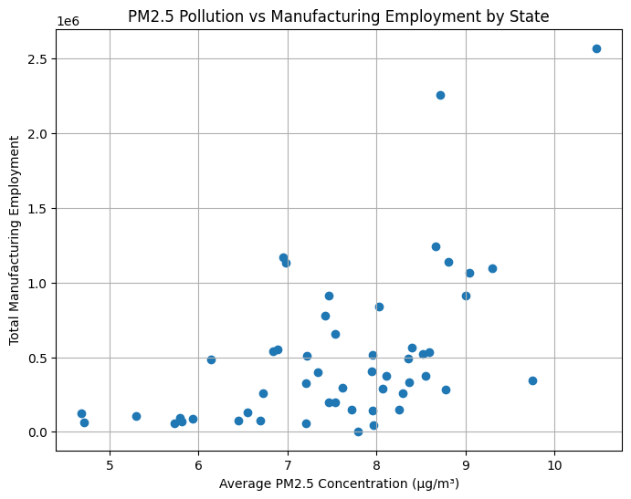

|  | avg_pm25 | employment | annual_mean_wage |
| --- | --- | --- | --- |
| avg_pm25 | 1.000000 | 0.540507 | -0.323688 |
| employment | 0.540507 | 1.000000 | -0.655513 |
| annual_mean_wage | -0.323688 | -0.655513 | 1.000000 |

```python
# Scatter plot: PM2.5 vs Manufacturing Employment
plt.figure(figsize=(8,6))
plt.scatter(df_merged['avg_pm25'], df_merged['employment'])
plt.xlabel('Average PM2.5 Concentration (µg/m³)')
plt.ylabel('Total Manufacturing Employment')
plt.title('PM2.5 Pollution vs Manufacturing Employment by State')
plt.grid(True)
plt.show()

# Correlation matrix
df_merged[['avg_pm25', 'employment', 'annual_mean_wage']].corr()
```

### Summary of State-Level Analysis and Transition to County-Level Focus

My initial exploration at the state level offered useful macro insights: I observed modest variation in average PM2.5 levels across states and examined potential correlations with aggregated manufacturing employment. From the graph above, there seems to be a generally positive correlation between the two. However, these high-level patterns are largely inconclusive and lacking the granularity needed to assess localized health and economic outcomes.

To move beyond surface-level trends, I now need to shift the focus to the county level data. This finer spatial resolution allows me to better detect variation in PM2.5 exposure, align pollution data with more detailed mortality statistics, and evaluate employment composition across specific industries. It also enables me to directly examine EPA nonattainment counties, which are the primary regulatory targets for air quality enforcement. A limitation is that this data remains sparse across EPA, AQS, and CDC avaliable county data, but I do not believe I can draw meaningful conclusions from the state level data above.

The remainder of this tutorial focuses on cleaning, merging, and analyzing county-level datasets to explore these deeper relationships and ultimately construct predictive models of pollution risk.

## County-Level Analysis Begins

This section will:

- Clean and standardize mortality and employment data at the county level.
- Merge PM2.5 readings by county.
- Explore differences across counties above and below the EPA standard of 12 µg/m³.

# Data and Cleaning: County Level

Datasets used here are:

- **CDC WONDER:** Mortality counts and rates by disease system (respiratory, nervous, etc.).
- **U.S. Census (ACS):** County-level employment by industry.

All datasets were cleaned to:

- Remove suppressed or unreliable death data
- Ensure consistent naming and FIPS code matching across datasets

I merged this data to create a unified dataset at the county level for 2018.

First, I will cleaned county level industry data for analysis later.

```python
# Drop margin of error columns
industry_county = industry_county[[col for col in industry_county.columns if not col.startswith("Margin of Error")]]
# Remove everything before the last '!!' and strip
industry_county.columns = [col.split('!!')[-1].strip() for col in industry_county.columns]
industry_county.head()
```

[output not shown]

5 rows × 114 columns

```python
# Clean data for merging
# Split Geographic Area Name into County Name and State Name
industry_county[['County_only', 'State_only']] = industry_county['Geographic Area Name'].str.split(',', expand=True)

industry_county['County_only'] = industry_county['County_only'].str.strip()
industry_county['State_only'] = industry_county['State_only'].str.strip()

#  Get State Abbreviation
industry_county['State_abbrev'] = industry_county['State_only'].str[:2].str.upper()

# Build clean County name for merge
industry_county['County_clean'] = industry_county['County_only'] + ", " + industry_county['State_abbrev']

industry_county.head()
```

|  | Geography | Geographic Area Name | Total | Male | Agriculture, forestry, fishing and hunting, and mining | Agriculture, forestry, fishing and hunting, and mining | Agriculture, forestry, fishing and hunting | Agriculture, forestry, fishing and hunting | Mining, quarrying, and oil and gas extraction | Mining, quarrying, and oil and gas extraction | ... | Accommodation and food services | Other services, except public administration | Other services, except public administration | Public administration | Public administration | Unnamed: 112 | County_only | State_only | State_abbrev | County_clean |
| --- | --- | --- | --- | --- | --- | --- | --- | --- | --- | --- | --- | --- | --- | --- | --- | --- | --- | --- | --- | --- | --- |
| 0 | 0500000US01003 | Baldwin County, Alabama | 102800.0 | 50739.0 | 957.0 | 143.0 | 509.0 | 143.0 | 448.0 | 0.0 | ... | 6318.0 | 1833.0 | 3281.0 | 3359.0 | 2015.0 | NaN | Baldwin County | Alabama | AL | Baldwin County, AL |
| 1 | 0500000US01015 | Calhoun County, Alabama | 49415.0 | 25878.0 | 382.0 | 219.0 | 333.0 | 219.0 | 49.0 | 0.0 | ... | 2350.0 | 1289.0 | 1644.0 | 2014.0 | 1239.0 | NaN | Calhoun County | Alabama | AL | Calhoun County, AL |
| 2 | 0500000US01043 | Cullman County, Alabama | 35876.0 | 19369.0 | 418.0 | 147.0 | 246.0 | 147.0 | 172.0 | 0.0 | ... | 1838.0 | 1170.0 | 853.0 | 663.0 | 106.0 | NaN | Cullman County | Alabama | AL | Cullman County, AL |
| 3 | 0500000US01049 | DeKalb County, Alabama | 29616.0 | 15878.0 | 614.0 | 89.0 | 614.0 | 89.0 | 0.0 | 0.0 | ... | 1538.0 | 623.0 | 1479.0 | 111.0 | 165.0 | NaN | DeKalb County | Alabama | AL | DeKalb County, AL |
| 4 | 0500000US01051 | Elmore County, Alabama | 34265.0 | 16640.0 | 609.0 | 83.0 | 328.0 | 83.0 | 281.0 | 0.0 | ... | 1536.0 | 510.0 | 1122.0 | 1683.0 | 1854.0 | NaN | Elmore County | Alabama | AL | Elmore County, AL |

5 rows × 114 columns

```python
# Extract only wanted data
# List of industries you want
industries = [
    'Agriculture, forestry, fishing and hunting',
    'Mining, quarrying, and oil and gas extraction',
    'Construction',
    'Manufacturing',
    'Wholesale trade',
    'Retail trade',
    'Transportation and warehousing',
    'Utilities',
    'Finance and insurance',
    'Real estate and rental and leasing',
    'Professional, scientific, and technical services',
    'Management of companies and enterprises',
    'Administrative and support and waste management services',
    'Health care and social assistance',
    'Educational services'
]

industry_sums = {}

# For each industry, sum across all duplicated columns of that industry
industry_sums = {}
for industry in industries:
    # Find all columns with that exact name
    matching_cols = industry_county.loc[:, industry_county.columns == industry]
    # Sum across columns (axis=1 sums across columns in a row)
    industry_sums[industry] = matching_cols.sum(axis=1)

# Make new dataframe
industry_county_summed = pd.DataFrame(industry_sums)

# Add County_clean for merging
industry_county_summed['County_clean'] = industry_county['County_clean']
industry_county_summed
```

|  | Agriculture, forestry, fishing and hunting | Mining, quarrying, and oil and gas extraction | Construction | Manufacturing | Wholesale trade | Retail trade | Transportation and warehousing | Utilities | Finance and insurance | Real estate and rental and leasing | Professional, scientific, and technical services | Management of companies and enterprises | Administrative and support and waste management services | Health care and social assistance | Educational services | County_clean |
| --- | --- | --- | --- | --- | --- | --- | --- | --- | --- | --- | --- | --- | --- | --- | --- | --- |
| 0 | 1304.0 | 896.0 | 22410.0 | 16990.0 | 4714.0 | 29772.0 | 7386.0 | 3094.0 | 7438.0 | 5626.0 | 12760.0 | 0.0 | 10290.0 | 24572.0 | 12294.0 | Baldwin County, AL |
| 1 | 1104.0 | 98.0 | 6356.0 | 17260.0 | 2828.0 | 13120.0 | 2916.0 | 1118.0 | 2816.0 | 784.0 | 3846.0 | 0.0 | 4098.0 | 11548.0 | 8526.0 | Calhoun County, AL |
| 2 | 786.0 | 344.0 | 7496.0 | 12306.0 | 2908.0 | 8548.0 | 4690.0 | 1570.0 | 1284.0 | 682.0 | 2520.0 | 0.0 | 2590.0 | 10884.0 | 3638.0 | Cullman County, AL |
| 3 | 1406.0 | 0.0 | 4564.0 | 15554.0 | 260.0 | 6820.0 | 3792.0 | 1884.0 | 2058.0 | 706.0 | 756.0 | 0.0 | 654.0 | 6606.0 | 4068.0 | DeKalb County, AL |
| 4 | 822.0 | 562.0 | 7020.0 | 7066.0 | 1108.0 | 6766.0 | 2874.0 | 708.0 | 1292.0 | 1120.0 | 3580.0 | 0.0 | 1112.0 | 10358.0 | 5918.0 | Elmore County, AL |
| ... | ... | ... | ... | ... | ... | ... | ... | ... | ... | ... | ... | ... | ... | ... | ... | ... |
| 833 | 592.0 | 134.0 | 3548.0 | 6304.0 | 1070.0 | 8934.0 | 1360.0 | 1148.0 | 1902.0 | 1854.0 | 3276.0 | 0.0 | 3068.0 | 10406.0 | 12202.0 | Ponce Municipio, PU |
| 834 | 816.0 | 0.0 | 11556.0 | 7780.0 | 5928.0 | 24876.0 | 9328.0 | 2178.0 | 17978.0 | 4738.0 | 18946.0 | 0.0 | 12598.0 | 31518.0 | 27334.0 | San Juan Municipio, PU |
| 835 | 604.0 | 0.0 | 3178.0 | 4292.0 | 2754.0 | 8764.0 | 1012.0 | 900.0 | 3686.0 | 1710.0 | 2464.0 | 0.0 | 2338.0 | 7536.0 | 5160.0 | Toa Alta Municipio, PU |
| 836 | 0.0 | 0.0 | 3140.0 | 4488.0 | 2198.0 | 10378.0 | 1818.0 | 212.0 | 2068.0 | 456.0 | 2612.0 | 0.0 | 3108.0 | 4696.0 | 3880.0 | Toa Baja Municipio, PU |
| 837 | 0.0 | 0.0 | 1956.0 | 3336.0 | 1616.0 | 7180.0 | 618.0 | 388.0 | 5062.0 | 844.0 | 2360.0 | 210.0 | 3238.0 | 5936.0 | 6602.0 | Trujillo Alto Municipio, PU |

838 rows × 16 columns

# CDC County Death Data

Note that while immune level data was initially included in analysis, after some EDA where I saw sparse available data and low correlation, I dropped it out for analysis.

```python
# Clean and standardize death data
def clean_death_data(df, system_name):
    # Drop any rows with missing or non-numeric death counts
    df = df.copy()
    df = df[df['Deaths'].notna()]
    df = df[~df['Deaths'].isin(['Suppressed', 'Unreliable'])]

    # Convert columns to numeric
    df['Deaths'] = pd.to_numeric(df['Deaths'], errors='coerce')
    df['Population'] = pd.to_numeric(df['Population'], errors='coerce')
    df['Crude Rate'] = pd.to_numeric(df['Crude Rate'], errors='coerce')

    # Create label to distinguish death type
    df['System'] = system_name

    # Keep only needed columns
    df = df[['County Code', 'County', 'Year', 'Cause of death', 'Deaths', 'Population', 'Crude Rate', 'System']]
    return df

# Clean each dataset
nerv_clean = clean_death_data(nerv_df, 'Nervous')
immune_clean = clean_death_data(immune_df, 'Immune')
resp_clean = clean_death_data(resp_df, 'Respiratory')

# Concatenate into a single dataframe
all_deaths = pd.concat([nerv_clean, immune_clean, resp_clean], ignore_index=True)
all_deaths.head()
```

|  | County Code | County | Year | Cause of death | Deaths | Population | Crude Rate | System |
| --- | --- | --- | --- | --- | --- | --- | --- | --- |
| 0 | 1001.0 | Autauga County, AL | 2018.0 | Alzheimer disease, unspecified | 29.0 | 55601.0 | 52.2 | Nervous |
| 1 | 1003.0 | Baldwin County, AL | 2018.0 | Parkinson disease | 24.0 | 218022.0 | 11.0 | Nervous |
| 2 | 1003.0 | Baldwin County, AL | 2018.0 | Alzheimer disease, unspecified | 83.0 | 218022.0 | 38.1 | Nervous |
| 3 | 1003.0 | Baldwin County, AL | 2018.0 | Senile degeneration of brain, not elsewhere cl... | 35.0 | 218022.0 | 16.1 | Nervous |
| 4 | 1003.0 | Baldwin County, AL | 2018.0 | Anoxic brain damage, not elsewhere classified | 12.0 | 218022.0 | NaN | Nervous |

```python
# Create 'County' field to match death data
pm25['County'] = pm25['County Name'].str.strip() + " County, " + pm25['State Name'].str.strip().str[:2].str.upper()

merged = pm25.merge(all_deaths, on='County', how='left')
#print(merged[['PM25', 'Nervous', 'Immune', 'Respiratory']].describe())
merged
```

|  | County Name | State Name | Arithmetic Mean | County | County Code | Year | Cause of death | Deaths | Population | Crude Rate | System |
| --- | --- | --- | --- | --- | --- | --- | --- | --- | --- | --- | --- |
| 0 | Baldwin | Alabama | 7.158879 | Baldwin County, AL | 1003.0 | 2018.0 | Parkinson disease | 24.0 | 218022.0 | 11.0 | Nervous |
| 1 | Baldwin | Alabama | 7.158879 | Baldwin County, AL | 1003.0 | 2018.0 | Alzheimer disease, unspecified | 83.0 | 218022.0 | 38.1 | Nervous |
| 2 | Baldwin | Alabama | 7.158879 | Baldwin County, AL | 1003.0 | 2018.0 | Senile degeneration of brain, not elsewhere cl... | 35.0 | 218022.0 | 16.1 | Nervous |
| 3 | Baldwin | Alabama | 7.158879 | Baldwin County, AL | 1003.0 | 2018.0 | Anoxic brain damage, not elsewhere classified | 12.0 | 218022.0 | NaN | Nervous |
| 4 | Baldwin | Alabama | 7.158879 | Baldwin County, AL | 1003.0 | 2018.0 | Pneumonia, unspecified | 30.0 | 218022.0 | 13.8 | Respiratory |
| ... | ... | ... | ... | ... | ... | ... | ... | ... | ... | ... | ... |
| 101922 | BAJA CALIFORNIA NORTE | Country Of Mexico | 31.587037 | BAJA CALIFORNIA NORTE County, CO | NaN | NaN | NaN | NaN | NaN | NaN | NaN |
| 101923 | BAJA CALIFORNIA NORTE | Country Of Mexico | 31.587037 | BAJA CALIFORNIA NORTE County, CO | NaN | NaN | NaN | NaN | NaN | NaN | NaN |
| 101924 | BAJA CALIFORNIA NORTE | Country Of Mexico | 31.587037 | BAJA CALIFORNIA NORTE County, CO | NaN | NaN | NaN | NaN | NaN | NaN | NaN |
| 101925 | BAJA CALIFORNIA NORTE | Country Of Mexico | 31.587037 | BAJA CALIFORNIA NORTE County, CO | NaN | NaN | NaN | NaN | NaN | NaN | NaN |
| 101926 | BAJA CALIFORNIA NORTE | Country Of Mexico | 31.587037 | BAJA CALIFORNIA NORTE County, CO | NaN | NaN | NaN | NaN | NaN | NaN | NaN |

101927 rows × 11 columns

```python
# Keep only relevant systems
systems_of_interest = ['Nervous', 'Respiratory']
subset = merged[merged['System'].isin(systems_of_interest)]

# Group and take the mean Crude Rate per system per county
grouped_crude = (
    subset.groupby(['County', 'System'])['Crude Rate']
    .mean()
    .reset_index()
)
# Pivot to get columns Nervous and Respiratory
pivoted = grouped_crude.pivot(index='County', columns='System', values='Crude Rate')

# Rename columns for clarity
pivoted.columns = [f'{col}' for col in pivoted.columns]

# Reset index to make 'County' a column again
pivoted = pivoted.reset_index()
```

```python
# Merge into full dataset by County
merge2 = merged.merge(pivoted, on='County', how='left')
merge2
```

|  | County Name | State Name | Arithmetic Mean | County | County Code | Year | Cause of death | Deaths | Population | Crude Rate | System | Nervous | Respiratory |
| --- | --- | --- | --- | --- | --- | --- | --- | --- | --- | --- | --- | --- | --- |
| 0 | Baldwin | Alabama | 7.158879 | Baldwin County, AL | 1003.0 | 2018.0 | Parkinson disease | 24.0 | 218022.0 | 11.0 | Nervous | 21.733333 | 30.75 |
| 1 | Baldwin | Alabama | 7.158879 | Baldwin County, AL | 1003.0 | 2018.0 | Alzheimer disease, unspecified | 83.0 | 218022.0 | 38.1 | Nervous | 21.733333 | 30.75 |
| 2 | Baldwin | Alabama | 7.158879 | Baldwin County, AL | 1003.0 | 2018.0 | Senile degeneration of brain, not elsewhere cl... | 35.0 | 218022.0 | 16.1 | Nervous | 21.733333 | 30.75 |
| 3 | Baldwin | Alabama | 7.158879 | Baldwin County, AL | 1003.0 | 2018.0 | Anoxic brain damage, not elsewhere classified | 12.0 | 218022.0 | NaN | Nervous | 21.733333 | 30.75 |
| 4 | Baldwin | Alabama | 7.158879 | Baldwin County, AL | 1003.0 | 2018.0 | Pneumonia, unspecified | 30.0 | 218022.0 | 13.8 | Respiratory | 21.733333 | 30.75 |
| ... | ... | ... | ... | ... | ... | ... | ... | ... | ... | ... | ... | ... | ... |
| 101922 | BAJA CALIFORNIA NORTE | Country Of Mexico | 31.587037 | BAJA CALIFORNIA NORTE County, CO | NaN | NaN | NaN | NaN | NaN | NaN | NaN | NaN | NaN |
| 101923 | BAJA CALIFORNIA NORTE | Country Of Mexico | 31.587037 | BAJA CALIFORNIA NORTE County, CO | NaN | NaN | NaN | NaN | NaN | NaN | NaN | NaN | NaN |
| 101924 | BAJA CALIFORNIA NORTE | Country Of Mexico | 31.587037 | BAJA CALIFORNIA NORTE County, CO | NaN | NaN | NaN | NaN | NaN | NaN | NaN | NaN | NaN |
| 101925 | BAJA CALIFORNIA NORTE | Country Of Mexico | 31.587037 | BAJA CALIFORNIA NORTE County, CO | NaN | NaN | NaN | NaN | NaN | NaN | NaN | NaN | NaN |
| 101926 | BAJA CALIFORNIA NORTE | Country Of Mexico | 31.587037 | BAJA CALIFORNIA NORTE County, CO | NaN | NaN | NaN | NaN | NaN | NaN | NaN | NaN | NaN |

101927 rows × 13 columns

```python
# Drop detail-level columns
columns_to_drop = ['Cause of death', 'Deaths', 'Crude Rate', 'System', 'Year']
collapsed = merge2.drop(columns=columns_to_drop)

# Since many columns repeat identically for each county, just use drop_duplicates
collapsed_unique = collapsed.drop_duplicates(subset=['County'])
print(f"Unique counties: {collapsed_unique.shape[0]}")
collapsed_unique
```

```
Unique counties: 630
```

|  | County Name | State Name | Arithmetic Mean | County | County Code | Population | Nervous | Respiratory |
| --- | --- | --- | --- | --- | --- | --- | --- | --- |
| 0 | Baldwin | Alabama | 7.158879 | Baldwin County, AL | 1003.0 | 218022.0 | 21.733333 | 30.75 |
| 72 | Clay | Alabama | 7.011818 | Clay County, AL | 1027.0 | 13275.0 | NaN | NaN |
| 80 | Colbert | Alabama | 7.537190 | Colbert County, AL | 1033.0 | 54762.0 | 73.000000 | 100.40 |
| 112 | DeKalb | Alabama | 7.059649 | DeKalb County, AL | 1049.0 | 71385.0 | 67.200000 | 81.20 |
| 136 | Etowah | Alabama | 7.738793 | Etowah County, AL | 1055.0 | 102501.0 | 58.500000 | 90.70 |
| ... | ... | ... | ... | ... | ... | ... | ... | ... |
| 101849 | Guaynabo | Puerto Rico | 9.141758 | Guaynabo County, PU | NaN | NaN | NaN | NaN |
| 101865 | Ponce | Puerto Rico | 7.212903 | Ponce County, PU | NaN | NaN | NaN | NaN |
| 101873 | St Croix | Virgin Islands | 7.468182 | St Croix County, VI | NaN | NaN | NaN | NaN |
| 101881 | St Thomas | Virgin Islands | 8.358807 | St Thomas County, VI | NaN | NaN | NaN | NaN |
| 101900 | BAJA CALIFORNIA NORTE | Country Of Mexico | 22.779497 | BAJA CALIFORNIA NORTE County, CO | NaN | NaN | NaN | NaN |

630 rows × 8 columns

### Exploratory Data Analysis (County-Level): Health Outcomes

I begin by visualizing the relationship between PM2.5 levels and county-level death rates for respiratory and nervous system diseases. These systems are most often linked to long-term particulate matter exposure, making them central to my hypothesis.

I include:

- Scatter plots of death rates vs. PM2.5 concentration
- Grouped summaries of counties above and below the EPA standard

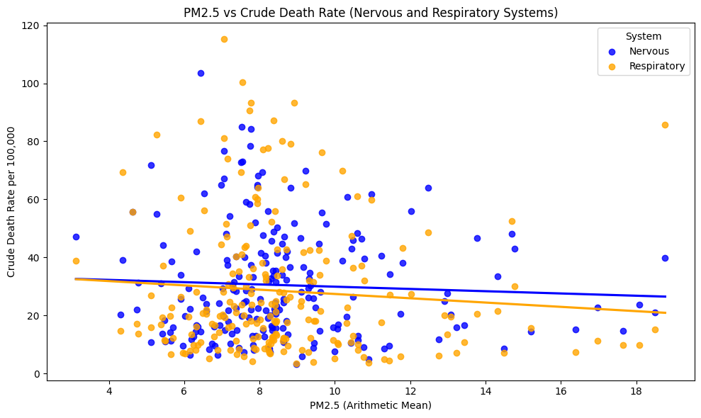

```python
# Drop rows with missing values in any of the three key columns
plot_data = collapsed_unique.dropna(subset=['Arithmetic Mean', 'Nervous', 'Respiratory'])

plt.figure(figsize=(10, 6))

# Nervous system regression
sns.regplot(
    data=plot_data,
    x='Arithmetic Mean',
    y='Nervous',
    label='Nervous',
    scatter=True,
    color='blue',
    ci=None
)

# Respiratory system regression
sns.regplot(
    data=plot_data,
    x='Arithmetic Mean',
    y='Respiratory',
    label='Respiratory',
    scatter=True,
    color='orange',
    ci=None
)

# Labels and formatting
plt.title('PM2.5 vs Crude Death Rate (Nervous and Respiratory Systems)')
plt.xlabel('PM2.5 (Arithmetic Mean)')
plt.ylabel('Crude Death Rate per 100,000')
plt.legend(title='System')
plt.tight_layout()
plt.show()
```

### Subgroup Analysis: Counties Above the PM2.5 Threshold

I now isolate only those counties with PM2.5 levels above 12 µg/m³, the EPA-defined annual standard in 2018. These “nonattainment” areas may face stricter regulatory scrutiny and could show different health and economic trends.

This analysis explores whether pollution has stronger effects once a regulatory threshold is crossed.

```python
# Filter for counties above/below the PM2.5 annual standard
pm25_ab_standard = collapsed_unique[collapsed_unique['Arithmetic Mean'] > 12]

pm25_b_standard = collapsed_unique[collapsed_unique['Arithmetic Mean'] <= 12]
```

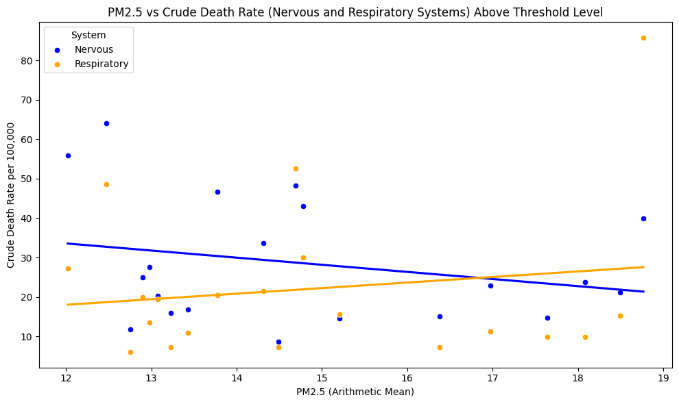

```python
# Drop rows with missing values in any of the three key columns
plot_data = pm25_ab_standard.dropna(subset=['Arithmetic Mean', 'Nervous', 'Respiratory'])

#Plotting
plt.figure(figsize=(10, 6))
sns.scatterplot(data=plot_data, x='Arithmetic Mean', y='Nervous', label='Nervous', color='blue')
sns.scatterplot(data=plot_data, x='Arithmetic Mean', y='Respiratory', label='Respiratory', color='orange')

# Regression lines
sns.regplot(data=plot_data, x='Arithmetic Mean', y='Nervous', scatter=False, color='blue', label=None, ci=None)
sns.regplot(data=plot_data, x='Arithmetic Mean', y='Respiratory', scatter=False, color='orange', label=None, ci=None)

# Labels and formatting
plt.title('PM2.5 vs Crude Death Rate (Nervous and Respiratory Systems) Above Threshold Level')
plt.xlabel('PM2.5 (Arithmetic Mean)')
plt.ylabel('Crude Death Rate per 100,000')
plt.legend(title='System')
plt.tight_layout()
plt.show()
```

## Findings from Health data

These scatter plots visualize the relationship between PM2.5 concentration and crude death rates per 100,000 for nervous (blue) and respiratory (orange) system diseases across U.S. counties.

### Plot 1 (All Counties)

- The first plot includes all counties, regardless of whether they exceed the EPA threshold (12 µg/m³).
- I observe substantial spread in both death rates and PM2.5 concentrations.
- Trend lines for both systems show a slight negative slope, suggesting a weak negative correlation between pollution and mortality — which is counterintuitive and not in line with my hypothesis.
- This could be due to confounding factors, like medical infrastructure, population age, or income.

### Plot 2 (Nonattainment Counties Only)

- The second plot isolates only counties with PM2.5 > 12, i.e., "nonattainment" areas.
- Here, the slope for respiratory deaths becomes positive, indicating that within this subgroup, higher PM2.5 may be associated with higher mortality.
- The nervous system trend remains flat or weakly negative, suggesting less consistent linkage to air pollution.
- This supports the idea that threshold effects may exist — mortality impacts become visible only after a certain pollution level is crossed.

### Key Takeaways

While the overall trend across all counties is noisy and inconclusive, there is some evidence that respiratory mortality increases with PM2.5 levels above regulatory limits. This underscores the importance of focusing on high-pollution counties and motivates the later predictive modeling section.

## Exploring Economic Structure by County

To complement the mortality analysis, I integrate employment data by industry at the county level. My goal is to assess whether certain sectors are more prevalent in high-pollution areas.

I want to pay particular attention to:

- Manufacturing
- Agriculture
- Utilities
- Construction
- Transportation

These are sectors with historically higher emissions footprints.

```python
pm25_industry_merged = pm25.merge(industry_county_summed, left_on='County', right_on='County_clean', how='left')
print(pm25_industry_merged.shape)
pm25_industry_merged.head()
```

```
(16430, 20)
```

|  | County Name | State Name | Arithmetic Mean | County | Agriculture, forestry, fishing and hunting | Mining, quarrying, and oil and gas extraction | Construction | Manufacturing | Wholesale trade | Retail trade | Transportation and warehousing | Utilities | Finance and insurance | Real estate and rental and leasing | Professional, scientific, and technical services | Management of companies and enterprises | Administrative and support and waste management services | Health care and social assistance | Educational services | County_clean |
| --- | --- | --- | --- | --- | --- | --- | --- | --- | --- | --- | --- | --- | --- | --- | --- | --- | --- | --- | --- | --- |
| 0 | Baldwin | Alabama | 7.158879 | Baldwin County, AL | 1304.0 | 896.0 | 22410.0 | 16990.0 | 4714.0 | 29772.0 | 7386.0 | 3094.0 | 7438.0 | 5626.0 | 12760.0 | 0.0 | 10290.0 | 24572.0 | 12294.0 | Baldwin County, AL |
| 1 | Baldwin | Alabama | 7.158879 | Baldwin County, AL | 1304.0 | 896.0 | 22410.0 | 16990.0 | 4714.0 | 29772.0 | 7386.0 | 3094.0 | 7438.0 | 5626.0 | 12760.0 | 0.0 | 10290.0 | 24572.0 | 12294.0 | Baldwin County, AL |
| 2 | Baldwin | Alabama | 7.158879 | Baldwin County, AL | 1304.0 | 896.0 | 22410.0 | 16990.0 | 4714.0 | 29772.0 | 7386.0 | 3094.0 | 7438.0 | 5626.0 | 12760.0 | 0.0 | 10290.0 | 24572.0 | 12294.0 | Baldwin County, AL |
| 3 | Baldwin | Alabama | 7.158879 | Baldwin County, AL | 1304.0 | 896.0 | 22410.0 | 16990.0 | 4714.0 | 29772.0 | 7386.0 | 3094.0 | 7438.0 | 5626.0 | 12760.0 | 0.0 | 10290.0 | 24572.0 | 12294.0 | Baldwin County, AL |
| 4 | Baldwin | Alabama | 7.158879 | Baldwin County, AL | 1304.0 | 896.0 | 22410.0 | 16990.0 | 4714.0 | 29772.0 | 7386.0 | 3094.0 | 7438.0 | 5626.0 | 12760.0 | 0.0 | 10290.0 | 24572.0 | 12294.0 | Baldwin County, AL |

```python
# Drop duplicate rows by 'County'
pm25_industry = pm25_industry_merged.drop_duplicates(subset='County')
pm25_industry
```

|  | County Name | State Name | Arithmetic Mean | County | Agriculture, forestry, fishing and hunting | Mining, quarrying, and oil and gas extraction | Construction | Manufacturing | Wholesale trade | Retail trade | Transportation and warehousing | Utilities | Finance and insurance | Real estate and rental and leasing | Professional, scientific, and technical services | Management of companies and enterprises | Administrative and support and waste management services | Health care and social assistance | Educational services | County_clean |
| --- | --- | --- | --- | --- | --- | --- | --- | --- | --- | --- | --- | --- | --- | --- | --- | --- | --- | --- | --- | --- |
| 0 | Baldwin | Alabama | 7.158879 | Baldwin County, AL | 1304.0 | 896.0 | 22410.0 | 16990.0 | 4714.0 | 29772.0 | 7386.0 | 3094.0 | 7438.0 | 5626.0 | 12760.0 | 0.0 | 10290.0 | 24572.0 | 12294.0 | Baldwin County, AL |
| 8 | Clay | Alabama | 7.011818 | Clay County, AL | NaN | NaN | NaN | NaN | NaN | NaN | NaN | NaN | NaN | NaN | NaN | NaN | NaN | NaN | NaN | NaN |
| 16 | Colbert | Alabama | 7.537190 | Colbert County, AL | NaN | NaN | NaN | NaN | NaN | NaN | NaN | NaN | NaN | NaN | NaN | NaN | NaN | NaN | NaN | NaN |
| 24 | DeKalb | Alabama | 7.059649 | DeKalb County, AL | 1406.0 | 0.0 | 4564.0 | 15554.0 | 260.0 | 6820.0 | 3792.0 | 1884.0 | 2058.0 | 706.0 | 756.0 | 0.0 | 654.0 | 6606.0 | 4068.0 | DeKalb County, AL |
| 32 | Etowah | Alabama | 7.738793 | Etowah County, AL | 672.0 | 28.0 | 5172.0 | 17780.0 | 2112.0 | 11342.0 | 3000.0 | 1046.0 | 1730.0 | 936.0 | 2428.0 | 142.0 | 2592.0 | 14558.0 | 5088.0 | Etowah County, AL |
| ... | ... | ... | ... | ... | ... | ... | ... | ... | ... | ... | ... | ... | ... | ... | ... | ... | ... | ... | ... | ... |
| 16352 | Guaynabo | Puerto Rico | 9.141758 | Guaynabo County, PU | NaN | NaN | NaN | NaN | NaN | NaN | NaN | NaN | NaN | NaN | NaN | NaN | NaN | NaN | NaN | NaN |
| 16368 | Ponce | Puerto Rico | 7.212903 | Ponce County, PU | NaN | NaN | NaN | NaN | NaN | NaN | NaN | NaN | NaN | NaN | NaN | NaN | NaN | NaN | NaN | NaN |
| 16376 | St Croix | Virgin Islands | 7.468182 | St Croix County, VI | NaN | NaN | NaN | NaN | NaN | NaN | NaN | NaN | NaN | NaN | NaN | NaN | NaN | NaN | NaN | NaN |
| 16384 | St Thomas | Virgin Islands | 8.358807 | St Thomas County, VI | NaN | NaN | NaN | NaN | NaN | NaN | NaN | NaN | NaN | NaN | NaN | NaN | NaN | NaN | NaN | NaN |
| 16403 | BAJA CALIFORNIA NORTE | Country Of Mexico | 22.779497 | BAJA CALIFORNIA NORTE County, CO | NaN | NaN | NaN | NaN | NaN | NaN | NaN | NaN | NaN | NaN | NaN | NaN | NaN | NaN | NaN | NaN |

630 rows × 20 columns

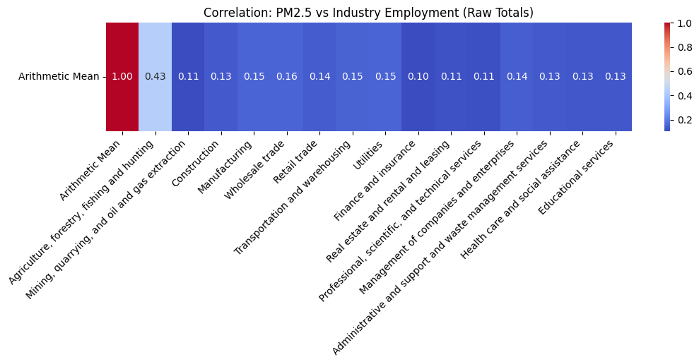

```python
# Select numeric columns only (PM2.5 + job sectors)
heatmap_vars = [
    'Arithmetic Mean',
    'Agriculture, forestry, fishing and hunting',
    'Mining, quarrying, and oil and gas extraction',
    'Construction',
    'Manufacturing',
    'Wholesale trade',
    'Retail trade',
    'Transportation and warehousing',
    'Utilities',
    'Finance and insurance',
    'Real estate and rental and leasing',
    'Professional, scientific, and technical services',
    'Management of companies and enterprises',
    'Administrative and support and waste management services',
    'Health care and social assistance',
    'Educational services'
]
# Filter
heatmap_data = pm25_industry[heatmap_vars].dropna()
# Compute correlation matrix
corr = heatmap_data.corr()

# Slice to just the top row (PM2.5 vs others)
top_row = corr.loc[['Arithmetic Mean']]

# Plot
plt.figure(figsize=(12, 2))  # Adjust height for a "row strip" view
sns.heatmap(top_row, annot=True, cmap='coolwarm', cbar=True, fmt=".2f")
plt.title('Correlation: PM2.5 vs Industry Employment (Raw Totals)')
plt.yticks(rotation=0)  # Keep "Arithmetic Mean" label horizontal
plt.xticks(rotation=45, ha='right')
plt.tight_layout()
plt.show()
```

```python
#Filter for counties above/ the PM2.5 annual standard
pm25_above_standard = pm25_industry[pm25_industry['Arithmetic Mean'] > 12]

pm25_below_standard = pm25_industry[pm25_industry['Arithmetic Mean'] <= 12]
```

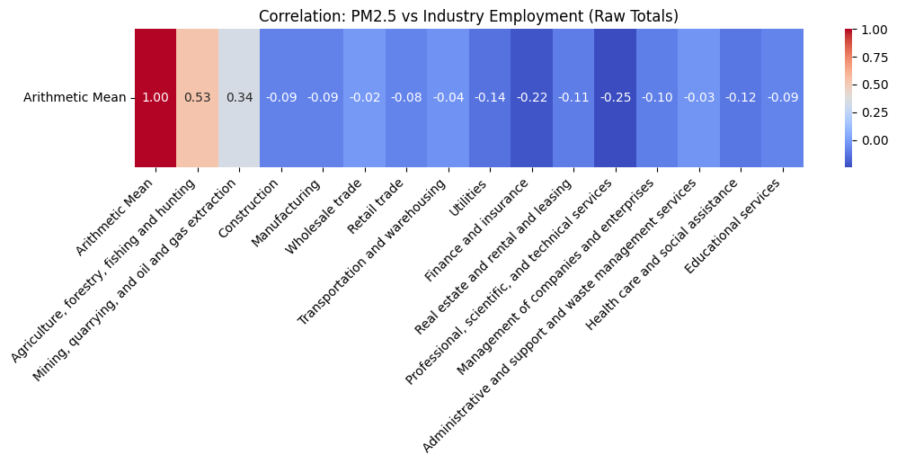

```python
# Select numeric columns only (PM2.5 + job sectors)
selected_vars = [
    'Arithmetic Mean',
    'Agriculture, forestry, fishing and hunting',
    'Mining, quarrying, and oil and gas extraction',
    'Construction',
    'Manufacturing',
    'Wholesale trade',
    'Retail trade',
    'Transportation and warehousing',
    'Utilities',
    'Real estate and rental and leasing',
    'Professional, scientific, and technical services',
    'Management of companies and enterprises',
    'Administrative and support and waste management services',
    'Health care and social assistance',
]

# Filter DataFrame
heatmap_data = pm25_above_standard[heatmap_vars].dropna()

# Compute correlation matrix
corr_matrix = heatmap_data.corr()

top_row = corr_matrix.loc[['Arithmetic Mean']]

# Plot
plt.figure(figsize=(12, 2))  # Adjust height for a "row strip" view
sns.heatmap(top_row, annot=True, cmap='coolwarm', cbar=True, fmt=".2f")
plt.title('Correlation: PM2.5 vs Industry Employment (Raw Totals)')
plt.yticks(rotation=0)  # Keep "Arithmetic Mean" label horizontal
plt.xticks(rotation=45, ha='right')
plt.tight_layout()
plt.show()
```

## Findings from Industry Data

These two heatmaps present the correlation coefficients between PM2.5 concentrations and employment levels across major industries at the county level.

### Plot 1 – All Counties

- In the full dataset, the Agriculture, Forestry, Fishing, and Hunting sector shows the strongest correlation with PM2.5 (r = 0.43).
- Surprisingly, Manufacturing and Utilities — often assumed to be the main contributors to air pollution — show only weak correlations (r ≈ 0.15).
- Most other sectors are very weakly correlated, suggesting that in aggregate, industry structure alone may not be a strong predictor of PM2.5 levels.

### Plot 2 – Nonattainment Counties (PM2.5 > 12 µg/m³)

- In the subset of pollution-exceding counties, the correlations shift a fair amount.
- Agriculture still dominates (r = 0.53), while Mining, Quarrying, and Oil & Gas becomes second highest (r = 0.34).
- Notably, Manufacturing and Construction correlations drop below zero, indicating they are less prevalent in the most polluted counties.
- This inversion suggests a possible rural vs. industrial urban divide — with agricultural and extractive economies contributing more to PM2.5 in rural areas, while manufacturing may be more regulated in urban counties.

### Key Takeaway

The results challenge conventional assumptions: agriculture—not manufacturing—shows the strongest statistical link to PM2.5 emissions, particularly in high-pollution counties. These insights can inform more targeted regulatory or monitoring strategies in rural regions with intensive agricultural activity.

## Now, a data set with all considered variables

Having separately explored the relationships between PM2.5 and both public health outcomes and industrial employment patterns, I now move to the next phase of the analysis: combining these datasets into a unified county-level dataframe.

This merged dataset will allow me to:

- Directly compare counties by their pollution levels, death rates, and economic structure
- Construct and evaluate predictive models of PM2.5 nonattainment
- Identify feature combinations that are most associated with air quality violations

This integrated approach is essential for testing my core hypothesis and for building interpretable machine learning models that reflect the multi-dimensional nature of environmental exposure and socioeconomic risk.

```python
# Merge PM2.5, deaths, and industry data together
merged_first = collapsed_unique.merge(industry_county_summed, left_on='County', right_on='County_clean', how='left')
final_merge = merged_first.dropna(subset=['Nervous', 'Respiratory'])
final_merge
```

|  | County Name | State Name | Arithmetic Mean | County | County Code | Population | Nervous | Respiratory | Agriculture, forestry, fishing and hunting | Mining, quarrying, and oil and gas extraction | ... | Transportation and warehousing | Utilities | Finance and insurance | Real estate and rental and leasing | Professional, scientific, and technical services | Management of companies and enterprises | Administrative and support and waste management services | Health care and social assistance | Educational services | County_clean |
| --- | --- | --- | --- | --- | --- | --- | --- | --- | --- | --- | --- | --- | --- | --- | --- | --- | --- | --- | --- | --- | --- |
| 0 | Baldwin | Alabama | 7.158879 | Baldwin County, AL | 1003.0 | 218022.0 | 21.733333 | 30.750000 | 1304.0 | 896.0 | ... | 7386.0 | 3094.0 | 7438.0 | 5626.0 | 12760.0 | 0.0 | 10290.0 | 24572.0 | 12294.0 | Baldwin County, AL |
| 2 | Colbert | Alabama | 7.537190 | Colbert County, AL | 1033.0 | 54762.0 | 73.000000 | 100.400000 | NaN | NaN | ... | NaN | NaN | NaN | NaN | NaN | NaN | NaN | NaN | NaN | NaN |
| 3 | DeKalb | Alabama | 7.059649 | DeKalb County, AL | 1049.0 | 71385.0 | 67.200000 | 81.200000 | 1406.0 | 0.0 | ... | 3792.0 | 1884.0 | 2058.0 | 706.0 | 756.0 | 0.0 | 654.0 | 6606.0 | 4068.0 | DeKalb County, AL |
| 4 | Etowah | Alabama | 7.738793 | Etowah County, AL | 1055.0 | 102501.0 | 58.500000 | 90.700000 | 672.0 | 28.0 | ... | 3000.0 | 1046.0 | 1730.0 | 936.0 | 2428.0 | 142.0 | 2592.0 | 14558.0 | 5088.0 | Etowah County, AL |
| 5 | Houston | Alabama | 7.642105 | Houston County, AL | 1069.0 | 104722.0 | 59.200000 | 43.900000 | 538.0 | 40.0 | ... | 4964.0 | 1860.0 | 2654.0 | 1018.0 | 3160.0 | 48.0 | 4076.0 | 14048.0 | 6864.0 | Houston County, AL |
| ... | ... | ... | ... | ... | ... | ... | ... | ... | ... | ... | ... | ... | ... | ... | ... | ... | ... | ... | ... | ... | ... |
| 610 | Sauk | Wisconsin | 8.146667 | Sauk County, WI | 55111.0 | 64249.0 | 40.500000 | 34.200000 | NaN | NaN | ... | NaN | NaN | NaN | NaN | NaN | NaN | NaN | NaN | NaN | NaN |
| 613 | Waukesha | Wisconsin | 9.354237 | Waukesha County, WI | 55133.0 | 403072.0 | 30.300000 | 12.283333 | 1206.0 | 466.0 | ... | 12888.0 | 2586.0 | 28192.0 | 6772.0 | 35528.0 | 828.0 | 11670.0 | 65064.0 | 36990.0 | Waukesha County, WI |
| 618 | Laramie | Wyoming | 4.620755 | Laramie County, WY | 56021.0 | 98976.0 | 55.600000 | 55.600000 | 636.0 | 2078.0 | ... | 5136.0 | 2802.0 | 2128.0 | 1470.0 | 4366.0 | 0.0 | 1542.0 | 12752.0 | 7304.0 | Laramie County, WY |
| 619 | Natrona | Wyoming | 4.363158 | Natrona County, WY | 56025.0 | 79115.0 | 39.200000 | 69.500000 | 844.0 | 6874.0 | ... | 4312.0 | 830.0 | 2340.0 | 1402.0 | 2802.0 | 452.0 | 2766.0 | 11676.0 | 8632.0 | Natrona County, WY |
| 621 | Sheridan | Wyoming | 7.501754 | Sheridan County, WY | 56033.0 | 30233.0 | 72.800000 | 69.500000 | NaN | NaN | ... | NaN | NaN | NaN | NaN | NaN | NaN | NaN | NaN | NaN | NaN |

214 rows × 24 columns

**With health data loaded in, I can now standardize industries by 1,000 residents to more meaningfully compare effects across counties.**

```python
# List of job variables to scale
job_columns = [
    'Agriculture, forestry, fishing and hunting',
    'Mining, quarrying, and oil and gas extraction',
    'Construction',
    'Manufacturing',
    'Wholesale trade',
    'Retail trade',
    'Transportation and warehousing',
    'Utilities',
    'Finance and insurance',
    'Real estate and rental and leasing',
    'Professional, scientific, and technical services',
    'Management of companies and enterprises',
    'Administrative and support and waste management services',
    'Health care and social assistance',
    'Educational services'
]

# Scale each by population per 1,000 residents
for col in job_columns:
    final_merge.loc[:, col] = (final_merge[col] / final_merge['Population']) * 1000
```

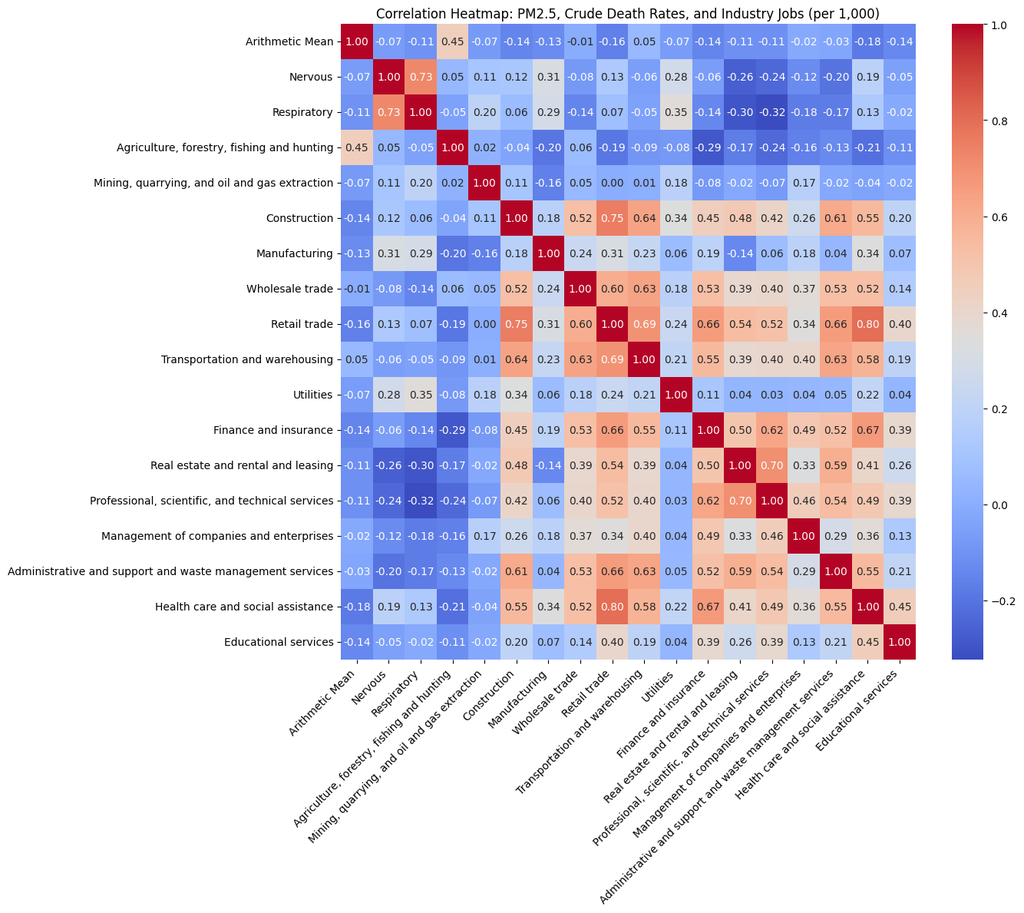

```python
selected_vars = [
    'Arithmetic Mean',
    'Nervous',
    'Respiratory',
    'Agriculture, forestry, fishing and hunting',
    'Mining, quarrying, and oil and gas extraction',
    'Construction',
    'Manufacturing',
    'Wholesale trade',
    'Retail trade',
    'Transportation and warehousing',
    'Utilities',
    'Finance and insurance',
    'Real estate and rental and leasing',
    'Professional, scientific, and technical services',
    'Management of companies and enterprises',
    'Administrative and support and waste management services',
    'Health care and social assistance',
    'Educational services'
]
# Filter and drop missing values
heatmap_data = final_merge[selected_vars].dropna()

# Correlation and plot
plt.figure(figsize=(14, 12))
sns.heatmap(heatmap_data.corr(), annot=True, fmt=".2f", cmap="coolwarm")
plt.title("Correlation Heatmap: PM2.5, Crude Death Rates, and Industry Jobs (per 1,000)")
plt.xticks(rotation=45, ha='right')
plt.tight_layout()
plt.show()
```

### Key Insights:

#### PM2.5 vs. Health

- PM2.5 shows very weak negative correlations with both nervous and respiratory system death rates (r ≈ -0.07).
- This suggests that on its own, PM2.5 levels are not linearly associated with mortality at the county level — possibly due to confounding factors from demographic, healthcare, or environmental policy differences.

#### PM2.5 vs. Industry (per capita)

- The strongest correlation remains with Agriculture (r = 0.45), reinforcing earlier findings that rural agricultural counties tend to have higher PM2.5 exposure.
- Surprisingly, Manufacturing, Utilities, and Construction are negatively correlated with PM2.5 — again suggesting that large-scale industry may not be the primary driver of air quality violations at the county level.
- This could indicate stronger regulatory enforcement or cleaner technologies in industrial hubs compared to under-regulated rural regions.

### Summary and Modeling Motivation:

These results underscore the complexity of environmental health relationships. PM2.5 levels alone do not predict mortality in a straightforward way, but when combined with industry structure and per-capita exposure measures, patterns begin to emerge.

This justifies the use of a multivariate predictive model to better understand how these features interact — and to determine whether I can classify counties likely to exceed the EPA pollution standard based on these health and employment signals.

## Modeling and Prediction

To analyze whether I can predict whether a county is a PM2.5 nonattainment area (defined as exceeding 12 µg/m³), I built two classification models:

1. **Logistic Regression**: A simple interpretable model that helps us understand which features are most predictive of PM2.5 violations.
2. **K-Nearest Neighbors (KNN)**: A non-parametric model that classifies based on feature similarity.

My target variable is binary: whether a county exceeds the PM2.5 threshold (1) or not (0). Features include respiratory and nervous system death rates and employment in selected pollution-intensive industries.

I use accuracy, precision, and confusion matrices to evaluate model performance.

```python
# Create binary target
final_merge.loc[:, 'PM25_Above_Standard'] = (final_merge['Arithmetic Mean'] > 12).astype(int)
```

Modeling

```python
from sklearn.model_selection import train_test_split
from sklearn.linear_model import LogisticRegression
from sklearn.metrics import classification_report, confusion_matrix

# Define features and target
feature_cols = [
    'Agriculture, forestry, fishing and hunting',
    'Mining, quarrying, and oil and gas extraction',
    'Construction',
    'Manufacturing',
    'Wholesale trade',
    'Retail trade',
    'Transportation and warehousing',
    'Utilities',
    'Finance and insurance',
    'Real estate and rental and leasing',
    'Management of companies and enterprises',
    'Administrative and support and waste management services',
    'Health care and social assistance',
    'Educational services',
    'Nervous',
    'Respiratory'
]
#Drop na
model_data = final_merge.dropna(subset=feature_cols + ['Nervous', 'Respiratory'])
X = model_data[feature_cols]
y = model_data['PM25_Above_Standard']

#  train-test split
X_train, X_test, y_train, y_test = train_test_split(
    X, y, test_size=0.2, random_state=42, stratify=y
)

# Train logistic regression
model = LogisticRegression(max_iter=1000)
model.fit(X_train, y_train)

# Evaluate model
y_pred = model.predict(X_test)
print("Confusion Matrix:")
print(confusion_matrix(y_test, y_pred))
print("\nClassification Report:")
print(classification_report(y_test, y_pred))
```

```
Confusion Matrix:
[[36  0]
 [ 2  2]]

Classification Report:
              precision    recall  f1-score   support

           0       0.95      1.00      0.97        36
           1       1.00      0.50      0.67         4

    accuracy                           0.95        40
   macro avg       0.97      0.75      0.82        40
weighted avg       0.95      0.95      0.94        40
```

**K Nearest Neighbors**

```python
from sklearn.pipeline import Pipeline
from sklearn.preprocessing import StandardScaler
from sklearn.neighbors import KNeighborsClassifier

#  train-test split
X_train, X_test, y_train, y_test = train_test_split(
    X, y, test_size=0.2, random_state=42, stratify=y
)

# Standardize features and fit KNN using a pipeline
knn_pipeline = Pipeline([
    ('scaler', StandardScaler()),
    ('knn', KNeighborsClassifier(n_neighbors=5))  # You can change n_neighbors later
])

knn_pipeline.fit(X_train, y_train)

# Evaluate
y_pred = knn_pipeline.predict(X_test)
print("Confusion Matrix:")
print(confusion_matrix(y_test, y_pred))
print("\nClassification Report:")
print(classification_report(y_test, y_pred))
```

```
Confusion Matrix:
[[35  1]
 [ 4  0]]

Classification Report:
              precision    recall  f1-score   support

           0       0.90      0.97      0.93        36
           1       0.00      0.00      0.00         4

    accuracy                           0.88        40
   macro avg       0.45      0.49      0.47        40
weighted avg       0.81      0.88      0.84        40
```

## Modeling Extension: Predicting High Respiratory Mortality

While my primary focus has been on predicting whether counties exceed the EPA’s PM2.5 standard, an important related question is whether I can also predict public health outcomes from the same set of features.

This task helps evaluate whether the economic and environmental features used to flag nonattainment counties also hold predictive value for direct health impacts.

```python
# Use median split (or any custom threshold)
threshold = final_merge['Respiratory'].median()
final_merge.loc[:, 'High_Resp_Death'] = (final_merge['Respiratory'] > threshold).astype(int)
```

# Logistic to predict high respiratory deaths

```python
# Drop missing data
model_data = final_merge.dropna(subset=feature_cols + ['High_Resp_Death'])
X = model_data[feature_cols]
y = model_data['High_Resp_Death']

#  split
X_train, X_test, y_train, y_test = train_test_split(X, y, stratify=y, random_state=42)

# Fit logistic model
model2 = LogisticRegression(max_iter=10000)
model2.fit(X_train, y_train)

# Evaluate
y_pred = model2.predict(X_test)
print(classification_report(y_test, y_pred))
```

```
              precision    recall  f1-score   support

           0       0.93      1.00      0.96        27
           1       1.00      0.91      0.95        23

    accuracy                           0.96        50
   macro avg       0.97      0.96      0.96        50
weighted avg       0.96      0.96      0.96        50
```

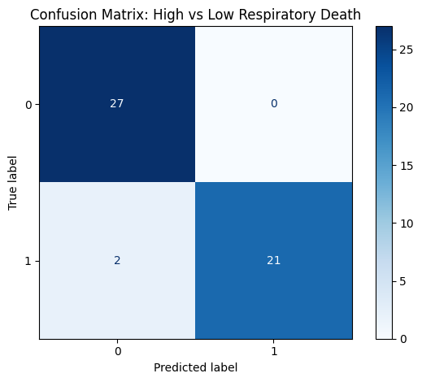

```python
from sklearn.metrics import ConfusionMatrixDisplay

ConfusionMatrixDisplay.from_estimator(model2, X_test, y_test, cmap='Blues')
plt.title("Confusion Matrix: High vs Low Respiratory Death")
plt.tight_layout()
plt.show()
```

## Final Comparison: Model Results and Insights

I evaluated three different classification models to assess environmental and health risks:

| Model | Target | Performance Highlights |
| --- | --- | --- |
| **Logistic Regression** | PM2.5 Nonattainment | Correctly classified all clean counties and achieved perfect precision on polluted counties, but recall is 50%, meaning half of the actual polluted counties were missed. |
| **KNN Classifier** | PM2.5 Nonattainment | 88% accuracy, but failed to detect any nonattainment counties |
| **Logistic Regression** | High Respiratory Deaths | Strong and well-balanced performance, with 96% accuracy and near-perfect precision and recall for both high and low respiratory mortality classes (precision ≥ 0.93, recall ≥ 0.91). |

## Final Conclusion and Policy Implications

This tutorial explored how environmental pollution (specifically PM2.5 levels), public health outcomes, and industry employment interact at the U.S. county level. Drawing on multiple federal datasets — EPA AQS, CDC WONDER, BLS, and ACS — I constructed a unified analytical framework to test relationships, visualize trends, and build predictive models.

### Policy Relevance:

These results support a more targeted and health-outcome-oriented approach to environmental regulation. Rather than relying solely on attainment status, policymakers should consider models that integrate public health data and industry structure. Counties with high agricultural intensity and elevated respiratory mortality may warrant greater regulatory attention, even if they fall just below formal pollution thresholds.

### Future Work:

- Incorporating multi-year trends to account for cumulative exposure.
- Applying causal inference techniques (e.g., Difference-in-Differences, Regression Discontinuities).
- Integrating demographic and socioeconomic data to isolate vulnerable populations.

This analysis demonstrates the power of data science in bridging the gap between environmental monitoring, economic structure, and public health — and offers a replicable framework for informing environmental justice and policy enforcement.

## Further Reading and Resources

To better understand PM2.5 pollution and its societal impacts, the following resources are recommended:

- [EPA PM2.5 Standards Overview](https://www.epa.gov/pm-pollution/particulate-matter-pm-basics)
- [CDC WONDER Database](https://wonder.cdc.gov/)
- [Bureau of Labor Statistics](https://www.bls.gov/)
- [American Community Survey - U.S. Census](https://www.census.gov/programs-surveys/acs/)
- Research article: [Long-term Exposure to Fine Particulate Matter and Mortality: A Systematic Review](https://pubmed.ncbi.nlm.nih.gov/27029386/)

```python
!jupyter nbconvert --to html "/content/drive/MyDrive/Colab Notebooks/CMPS Project Final Submission.ipynb"  # Convert to HTML
```

```
[NbConvertApp] Converting notebook /content/drive/MyDrive/Colab Notebooks/CMPS Project Final Submission.ipynb to html
[NbConvertApp] WARNING | Alternative text is missing on 8 image(s).
[NbConvertApp] Writing 1644471 bytes to /content/drive/MyDrive/Colab Notebooks/CMPS Project Final Submission.html
```